# C10 — Od wyniku do raportu: interpretacja, ograniczenia i odtwarzalność

Zarządzanie informacją — ćwiczenie i zadanie Z10 — 2026/27

ID: [UZUPELNIJ_ID]

2026/27

# Początek pracy na ćwiczeniu C10

Otwórz swój projekt kursu w Posit Cloud albo RStudio na własnym komputerze; pakiet kursu `badaniaZI` jest w nim zainstalowany. Dwa polecenia z następnego bloku wpisujesz w konsoli RStudio, czyli w dolnym panelu ze znakiem `>`; w miejsce `TWOJE_ID` wpisz swoje ID, a w miejsce `Imię Nazwisko` — swoje imię i nazwisko. Dokument PDF zawiera dwa polecenia jako tekst instrukcji.

```r
library(badaniaZI)
rozpocznij_zajecia("C10", id_studenta = "TWOJE_ID", student = "Imię Nazwisko")
```

Sprawdź w komunikacie ID oraz imię i nazwisko. Przy pierwszym starcie funkcja tworzy folder `moje-badania` i zapisuje w nim oba dane; pliki pracy zachowują je także po zamknięciu projektu, a imię i nazwisko trafiają do nazwy oddawanego pliku.

Funkcja `rozpocznij_zajecia()` otwiera własny plik `zadanie.Rmd`, zapamiętuje katalog pracy i kopiuje do folderu `moje-badania/materialy` wersję HTML i PDF ćwiczenia oraz rubrykę zadania. Pracuj w otwartym pliku `zadanie.Rmd` do końca zajęć. Najpierw uruchom blok `przygotowanie`, a potem kolejne części LEARN i CHALLENGE. Przy problemie poproś prowadzącego o pomoc; plik pracy i własne ID pozostają bez zmian.

Pierwszy chunk, `przygotowanie`, wczytuje gotowy skrypt `analiza.R`. Skrypt odczytuje wariant danych zapisany na C09, przygotowuje go po regułach ćwiczeń C02–C04 i liczy obie analizy projektu: porównanie indeksu w grupach (test Welcha, bootstrap osób, tasowanie etykiet) oraz tabelę 2 × 2 (test chi-kwadrat, tabele Monte Carlo, przedział różnicy odsetków) albo korelację rang Spearmana (test, tasowanie, bootstrap par). Skrypt zawiera też dwa przykłady LEARN dla ID demo001: scenariusz S02 ze ścieżką tabeli i scenariusz S05 ze ścieżką korelacji.

# Od liczb do odpowiedzi na pytanie

Na C09 powstała karta projektu: problem usługi, dwa pytania, znaczenie zmiennych, reguły przygotowania i pierwszy opis własnego wariantu danych. Na C10 praca toczy się na tym samym temacie i wariancie: gotowe bloki liczą obie analizy, a akapity opisują, co wynika z liczb dla pytania instytucji.

W przykładzie S02 biblioteka rozważa pomoc dla nowych użytkowników katalogu. Pierwsze pytanie dotyczy różnicy deklarowanej użyteczności katalogu między nowymi i doświadczonymi, drugie — różnicy odsetka osób, które znalazły wskazany dokument. Ocena katalogu opisuje deklarowaną użyteczność, a znalezienie dokumentu — wykonanie jednego zadania; zakres obu pomiarów wyznacza treść wniosku.

Raport prowadzi od problemu, przez pomiar i dane, do dwóch odpowiedzi i ograniczonej rekomendacji, a czytelnik sprawdza, skąd pochodzi każda liczba. Skrypt wykonuje obliczenia; akapity nadają liczbom znaczenie.

## Projekt: pięć akapitów Z10 w raporcie

Zadanie Z10 dostarcza pięciu z dziesięciu akapitów projektu. Akapit S01 staje się polem P05 raportu (kontrola danych), S02 — polem P07 (pierwsza analiza), S03 — polem P08 (druga analiza), S04 — polem P09 (wnioski i ograniczenia), a S05 — polem P10 (rekomendacja). Rozdział „Projekt końcowy: raport z dziesięciu akapitów” opisuje przejście od zadań Z09 i Z10 do raportu.

## Przebieg spotkania

Przeznacz około 5 minut na odtworzenie pracy, 30 minut na pięć bloków LEARN, 50 minut na pięć zadań CHALLENGE i 5 minut na zapis oraz oddanie. W LEARN czytasz pełny odczyt przykładu S02 i przykładu korelacyjnego S05. W CHALLENGE stosujesz ten sam tok do własnego wariantu z C09 i piszesz pięć akapitów pod wynikami, poza blokiem R. Gdy odczyt wyniku sprawia trudność, pytasz prowadzącego. Rozwinięcia po części obowiązkowej służą powtórce i redakcji raportu i pozostają poza oceną Z10.

Bloki LEARN kończą się **wzorcem zapisu** — przykładowym zdaniem według standardu APA (*Publication Manual of the American Psychological Association*, 7. wydanie, 2020): symbol statystyczny kursywą, stopnie swobody w nawiasie, przedział w nawiasie kwadratowym, przecinek jako separator dziesiętny. Na ćwiczeniu C10 wzorce dotyczą części wynikowej raportu: liczebności, porównania grup, tabeli 2 × 2, korelacji rang, syntezy i rekomendacji.

Publiczny podgląd materiału używa w CHALLENGE oznaczenia DEMO_C09. W pracy studenta wiersz „ID” manifestu podaje własne ID, a scenariusz, rocznik, wersja generatora i hash danych zgadzają się z kartą Z09.

# LEARN 1: Dane i mianownik każdej analizy

Raport zaczyna od kontroli: wariant, pomiar i zbiór osób zgadzają się z planem Z09. Przykład demo001 (S02) jest stałym przykładem kursu. Gotowy skrypt usuwa identyczne duplikaty, zamienia kod 99 w pozycjach ankiety na brak, oznacza czas spoza 0–120 minut jako brak czasu, odwraca pozycję 3 według $6-x$ i liczy indeks jako średnią co najmniej pięciu z sześciu ważnych pozycji. Indeks traktuje się jako zmienną ilościową; to założenie analizy, bo pojedyncza pozycja ma skalę porządkową.

```r
bilans_przykladu <- bilans_wariantu(wariant_demo)
print(bilans_przykladu)
```

**Bilans liczebności**

| Zakres | N |
| --- | --- |
| Rekordy surowe | 150 |
| Osoby po usunięciu duplikatów | 148 |
| Analiza 1: osoby z ważnym indeksem | 147 |
| Osoby z ważnym czasem | 142 |
| Analiza 2: osoby z wartością 0/1 | 148 |

**Dostępne pomiary w grupach**

| Grupa | Osoby | Ważny indeks | Ważny czas | Najdłuższy ważny czas [min] | Wartość 0/1 |
| --- | --- | --- | --- | --- | --- |
| doświadczeni | 74 | 74 | 70 | 30,2 | 74 |
| nowi | 74 | 73 | 72 | 33,8 | 74 |

Tabela „Bilans liczebności” podaje: ze 150 rekordów surowych zostaje 148 osób po usunięciu 2 identycznych powtórzeń, ważny indeks ma 147 osób, a druga analiza obejmuje 148 osób z wartością 0/1. Tabela „Dostępne pomiary w grupach” rozdziela ważne indeksy na 74 osoby doświadczone i 73 nowe. Druga analiza zachowuje 148 osób, bo jej zmiennymi są grupa i pole 0/1.

Każda analiza podaje własne N. Średnią liczy się z ważnych wartości, różnicę średnich — z dwóch zbiorów ważnych wartości, korelację — z kompletnych par tych samych osób, a N tabeli krzyżowej jest sumą jej komórek. Raport opisuje reguły przygotowania i ich liczbowy rezultat; losowość braków i reprezentatywność odpowiadających pozostają założeniami opisanymi w ograniczeniach.

```r
symbole <- symbole_do_odczytu()
print(symbole)
```

**Symbole wyniku i przykład z S02**

| Symbol | Znaczenie | Przykład z S02 |
| --- | --- | --- |
| $N$, $n_1$, $n_2$ | ważne osoby lub pary; liczebności grup | $N = 147$ (indeks); $n = 74$ i $n = 73$ |
| $\widehat\Delta$ | oszacowanie różnicy w jednostce pomiaru | $-0{,}438$ punktu indeksu |
| $SD$, $SE$ | rozrzut osób; niepewność estymaty | $SD = 0{,}704$ i $0{,}687$; $SE = 0{,}115$ |
| $CI$ | przedział dla parametru przy założeniach metody | $[-0{,}665; -0{,}212]$ (Welch) |
| $t$, $\chi^2$ | statystyka właściwego testu | $t(144{,}98) = -3{,}822$; $\chi^2(1) = 1{,}466$ |
| $p$, $p_{\mathrm{perm}}$, $p_{\mathrm{MC}}$ | skrajność wyniku przy modelu zerowym | $p = 0{,}0002$; $p_{\mathrm{perm}} = 0{,}001$; $p_{\mathrm{MC}} = 0{,}297$ |
| $B$, $k$ | liczba losowań; wyniki co najmniej tak skrajne | $B = 1999$, $k = 1$ (tasowanie etykiet) |

Tabela „Symbole wyniku i przykład z S02” zestawia siedem grup symboli z wartościami z przykładu. Każda metoda ma własny zestaw liczb: test Welcha — $t$, df i $p$; tabela 2 × 2 — $\chi^2$, df i $p$; korelacja rang Spearmana — $r_S$, $S$ i $p$ bez stopni swobody; opis średniej — średnią, SD i N.

**Wzorzec zapisu liczebności (APA).**

> Analizy objęły 148 osób po usunięciu 2 identycznych powtórzeń ze 150 rekordów surowych. Porównanie indeksu objęło 147 osób z ważnym indeksem (74 doświadczone, 73 nowe), a analiza wyniku zadania — 148 osób z wartością 0/1.

# LEARN 2: Pierwsza analiza — różnica ze znakiem i jednostką

Pierwsze pytanie S02 dotyczy tego, o ile średnia deklarowana użyteczność katalogu nowych różni się od średniej doświadczonych. Kontrast jest ustalony jako „nowi minus doświadczeni”; funkcja wypisuje kontrast każdego scenariusza w karcie „Analiza 1: kontrast i jednostka”.

$$\widehat{\Delta}=\bar{x}_{\text{nowi}}-\bar{x}_{\text{doświadczeni}},\qquad
SE=\sqrt{\frac{s_{\text{nowi}}^2}{n_{\text{nowi}}}+\frac{s_{\text{doświadczeni}}^2}{n_{\text{doświadczeni}}}},\qquad
t=\frac{\widehat{\Delta}}{SE},\qquad
CI_{95\%}=\widehat{\Delta}\pm t_{0{,}975;\,\nu}\,SE.$$

Pierwszy wzór odejmuje średnie w ustalonej kolejności i daje wynik w punktach indeksu. $SE$ łączy wariancje i liczebności obu grup bez założenia równych wariancji. Statystyka $t$ dzieli różnicę przez $SE$, więc jest liczbą bez jednostki, a przedział dodaje do różnicy $\pm t_{0{,}975;\nu}$ błędów standardowych, gdzie $\nu$ oznacza stopnie swobody Welcha. Ujemne $t$ i ujemna różnica wynikają z tego samego kontrastu. Bootstrap osób w grupach (wykład W03) daje drugi przedział z percentyli 2,5 i 97,5 różnic w $B=1999$ próbach bootstrapowych.

```r
pierwszy_wynik <- wynik_pierwszej_analizy(analizy_demo)
print(pierwszy_wynik)
```

**Analiza 1: kontrast i jednostka**

| Element | Treść |
| --- | --- |
| Pomiar | Ocena użyteczności katalogu |
| Kontrast | nowi minus doświadczeni |
| Jednostka różnicy | punkty indeksu 1–5 |

**Opis grup [pkt 1–5]**

| Grupa | n | Średnia | SD | Mediana |
| --- | --- | --- | --- | --- |
| doświadczeni | 74 | 3,510 | 0,704 | 3,500 |
| nowi | 73 | 3,072 | 0,687 | 3,167 |

**Test Welcha**

| Różnica [pkt] | SE | t | df | p |
| --- | --- | --- | --- | --- |
| −0,438 | 0,115 | −3,822 | 144,98 | 0,0002 |

**95% CI różnicy średnich [pkt]**

| Metoda | Różnica [pkt] | Dolna granica | Górna granica |
| --- | --- | --- | --- |
| Welch | −0,438 | −0,665 | −0,212 |
| Bootstrap w grupach | −0,438 | −0,659 | −0,227 |

**Tasowanie etykiet grup**

| Różnica obserwowana [pkt] | k | B | p_perm |
| --- | --- | --- | --- |
| −0,438 | 1 | 1999 | 0,0010 |

**Efekt standaryzowany**

| Różnica [pkt] | SD łączone | Hedges g |
| --- | --- | --- |
| −0,438 | 0,695 | −0,627 |

Tabela „Opis grup [pkt 1–5]” podaje średnie 3,510 ($n=74$) i 3,072 ($n=73$). Tabela „Test Welcha” podaje różnicę $-0{,}438$ punktu, $SE=0{,}115$, $t=-3{,}822$, $df=144{,}98$ i $p=0{,}0002$. Tabela „95% CI różnicy średnich [pkt]” podaje przedział Welcha $[-0{,}665; -0{,}212]$ i bootstrapowy $[-0{,}659; -0{,}227]$; tabela „Tasowanie etykiet grup” — $k=1$ i $p_{\mathrm{perm}}=0{,}0010$ przy $B=1999$; tabela „Efekt standaryzowany” — Hedges $g=-0{,}627$.

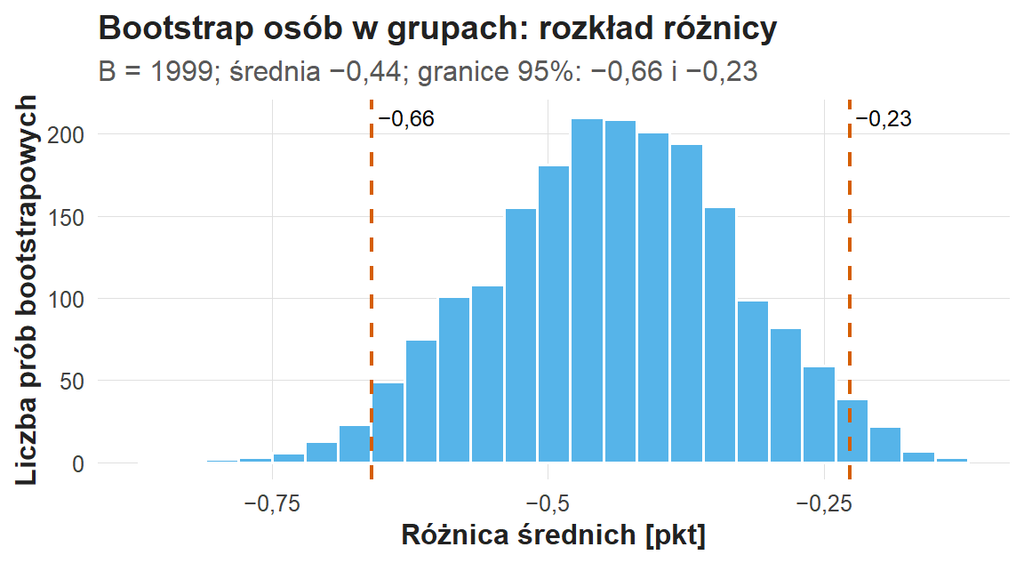

Tor bootstrapu w pierwszej analizie S02: 1999 różnic średnich z losowania osób ze zwracaniem w każdej grupie. Oś pozioma: różnica w punktach indeksu; linie przerywane oznaczają granice 95%, −0,66 i −0,23.

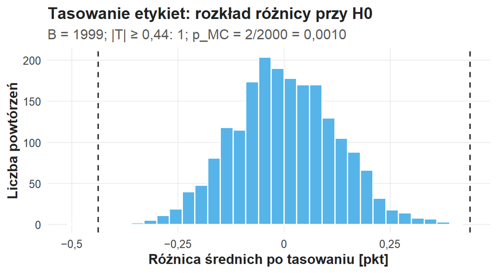

Tor tasowania w pierwszej analizie S02: 1999 różnic średnich po tasowaniu etykiet grup przy hipotezie zerowej. Linie przerywane oznaczają obserwowaną różnicę ±0,438; wartość co najmniej tak odległą od zera dało 1 tasowanie.

```r
tory <- wykres_dwa_tory(analizy_demo)
print(tory)
```

Wykres „Bootstrap osób w grupach: rozkład różnicy” przedstawia 1999 różnic bootstrapowych skupionych wokół $-0{,}44$ z granicami 95% równymi $-0{,}66$ i $-0{,}23$. Wykres „Tasowanie etykiet: rozkład różnicy przy H0” przedstawia 1999 różnic po tasowaniu skupionych wokół zera; wartość bezwzględną 0,438 osiągnęła jedna różnica z 1999, stąd $p_{\mathrm{perm}}=(1+1)/(1999+1)=0{,}001$. Bootstrap opisuje zmienność różnicy przy zachowanym podziale na grupy, a tasowanie buduje rozkład zerowy.

Różnica $-0{,}438$ jest wyrażona w punktach indeksu 1–5, a $g=-0{,}627$ — w jednostkach łączonego SD równego 0,695. Potrzebę zmiany katalogu ocenia się względem konstruktu i decyzji instytucji. Tasowanie etykiet wymaga wymienialności, a test Welcha dopuszcza nierówne wariancje; niezależność obserwacji i dobór do grup ocenia projekt badania.

**Wzorzec zapisu porównania grup (APA).**

> Nowi użytkownicy uzyskali niższy średni indeks użyteczności katalogu (*M* = 3,07; *SD* = 0,69; *n* = 73) niż doświadczeni (*M* = 3,51; *SD* = 0,70; *n* = 74). Różnica nowi minus doświadczeni wyniosła −0,44 punktu, 95% CI [−0,66; −0,21], *t*(144,98) = −3,82, *p* < 0,001, *g* = −0,63; bootstrapowy 95% CI wyniósł [−0,66; −0,23], a test permutacyjny (*B* = 1999) dał *p*<sub>perm</sub> = 0,001. Grupy są obserwacyjne, więc wynik opisuje związek stażu korzystania z oceną katalogu.

# LEARN 3: Druga analiza — inne pytanie, własne N i jednostka

W S02 drugie pytanie dotyczy odsetka osób, które znalazły dokument: analiza ma własne N (148 osób) i własną jednostkę efektu (punkty procentowe). Test Welcha i tasowanie etykiet to dwa tory pierwszego pytania, a tabela 2 × 2 odpowiada na drugie pytanie.

## Ścieżka tabeli 2 × 2: osoby, odsetki i punkty procentowe

$$\widehat{\pi}_g=\frac{x_g}{n_g},\qquad
\widehat{\Delta}_{pp}=100\,(\widehat{\pi}_{\text{nowi}}-\widehat{\pi}_{\text{doświadczeni}}),\qquad
V=\sqrt{\frac{\chi^2}{N}}.$$

Symbol $x_g$ oznacza liczbę osób z kodem 1 w grupie $g$, a $n_g$ — liczbę osób z ważną odpowiedzią w tej grupie. Mnożenie różnicy proporcji przez 100 zmienia jednostkę na punkty procentowe. Mianownikiem jest liczebność grupy; dzielenie przez łączną liczbę osób z kodem 1 opisywałoby skład grupy sukcesów, czyli inne pytanie. V Craméra dla tabeli 2 × 2 jest nieujemne: w S02 $V=\sqrt{1{,}466/148}=0{,}0995$, a kierunek podaje $\widehat{\Delta}_{pp}$.

```r
drugi_wynik <- wynik_drugiej_analizy(analizy_demo)
print(drugi_wynik)
```

**Analiza 2: pole 0/1**

| Element | Treść |
| --- | --- |
| Pytanie | Czy udało się znaleźć wskazany dokument? |
| Kod 1 | wskazano właściwą publikację i jej lokalizację lub dostęp |
| Źródło pola | obserwacja |
| Kontrast | nowi minus doświadczeni |
| Metoda główna | test chi-kwadrat bez korekty ciągłości (wszystkie liczebności oczekiwane co najmniej 5) |

**Liczby i odsetki kodu 1 w grupach**

| Grupa | Kod 0 | Kod 1 | n | Kod 1 [% grupy] |
| --- | --- | --- | --- | --- |
| doświadczeni | 22 | 52 | 74 | 70,3 |
| nowi | 29 | 45 | 74 | 60,8 |

**Test chi-kwadrat bez korekty ciągłości**

| N | Chi-kwadrat | df | p | Najmniejsza oczekiwana | Komórki z oczekiwaną < 5 |
| --- | --- | --- | --- | --- | --- |
| 148 | 1,466 | 1 | 0,2260 | 25,5 | 0 |

**Tabele Monte Carlo przy stałych marginesach**

| Chi-kwadrat obserwowane | k | B | p_MC |
| --- | --- | --- | --- |
| 1,466 | 593 | 1999 | 0,2970 |

**95% CI różnicy odsetków kodu 1 [pp]**

| Metoda | Różnica [pp] | Dolna granica | Górna granica |
| --- | --- | --- | --- |
| Przybliżenie dużopróbkowe | −9,46 | −24,70 | 5,78 |
| Bootstrap w grupach | −9,46 | −24,32 | 5,41 |

**V Craméra: natężenie bez kierunku**

| V |
| --- |
| 0,100 |

Karta „Analiza 2: pole 0/1” podaje treść pytania, znaczenie kodu 1, źródło pola i metodę główną. Tabela „Liczby i odsetki kodu 1 w grupach” podaje 52 z 74 doświadczonych (70,3%) i 45 z 74 nowych (60,8%). Tabela „Test chi-kwadrat bez korekty ciągłości” podaje $\chi^2(1)=1{,}466$, $p=0{,}2260$ i najmniejszą liczebność oczekiwaną 25,5; tabela „Tabele Monte Carlo przy stałych marginesach” — $k=593$ i $p_{\mathrm{MC}}=0{,}2970$ przy $B=1999$. Tabela „95% CI różnicy odsetków kodu 1 [pp]” podaje różnicę $-9{,}46$ pp z przedziałem dużopróbkowym $[-24{,}70; 5{,}78]$ i bootstrapowym $[-24{,}32; 5{,}41]$, a tabela „V Craméra: natężenie bez kierunku” — $V=0{,}100$.

Przy $\alpha=0{,}05$ hipoteza niezależności pozostaje, a przedział od $-24{,}7$ do $5{,}8$ pp obejmuje zarówno brak różnicy, jak i różnice praktycznie ważne. Dwie analizy opisują dwa pomiary o różnych jednostkach i precyzji: różnica ocen ma przedział po jednej stronie zera, a różnica odsetków — przedział obejmujący zero. Porównanie efektów obu analiz wymagałoby osobnego testu różnicy efektów.

Klasyczne $p$ (0,226) i $p_{\mathrm{MC}}$ (0,297) różnią się: pierwsze pochodzi z ciągłego przybliżenia rozkładem $\chi^2(1)$, drugie z dyskretnego rozkładu tabel o tych samych marginesach. Raport podaje oba $p$ i nazwę metody głównej. Przy liczebności oczekiwanej poniżej 5 funkcja dodaje tabelę „Test Fishera: iloraz szans z 95% CI”; przedział Fishera dotyczy ilorazu szans, a dużopróbkowy przedział różnicy odsetków wymaga wtedy ostrożnego odczytu.

**Wzorzec zapisu tabeli 2 × 2 (APA).**

> Wskazany dokument znalazło 45 z 74 nowych użytkowników (60,8%) i 52 z 74 doświadczonych (70,3%); różnica nowi minus doświadczeni wyniosła −9,46 punktu procentowego, 95% CI [−24,70; 5,78]. Test niezależności dał $\chi^2$(1) = 1,47, *p* = 0,226, a test Monte Carlo przy stałych marginesach (*B* = 1999) *p*<sub>MC</sub> = 0,297; *V* = 0,10. Przedział obejmuje zarówno brak różnicy, jak i różnice rzędu 20 punktów procentowych, więc wielkość różnicy skuteczności pozostaje nieustalona.

## Ścieżka korelacji: ten sam tok, inna estymanda

W scenariuszu korelacyjnym druga analiza opisuje związek indeksu z czasem albo z częstością korzystania. Przykład S05 (portal uczelni, ID demo001) jest odrębnym wariantem demonstracyjnym ścieżki korelacyjnej.

$$r_S=r\big(R(x),\,R(y)\big).$$

Współczynnik Spearmana to korelacja Pearsona rang $R(x)$ i $R(y)$ w kompletnych parach; remisy dostają rangi średnie (ćwiczenie C08). Współczynnik $r_S$ opisuje kierunek i siłę relacji monotonicznej osób z obiema wartościami, a parametr populacji oznacza się $\rho_S$. Wynik Spearmana raportuje się ze statystyką $S$, wartością $p$, przedziałem z bootstrapu par i $p$ z tasowania.

```r
wynik_korelacyjny <- wynik_drugiej_analizy(analizy_korelacji)
print(wynik_korelacyjny)
```

**Analiza 2: korelacja rang**

| Element | Treść |
| --- | --- |
| Zmienne | indeks oraz czas do zakończenia próby [min] |
| Współczynnik | rS Spearmana: liczba bez jednostki od −1 do 1 |
| Przedział | 95% CI z bootstrapu całych par |
| Tasowanie | jedna zmienna przestawiana względem drugiej przy niezależności |

**Kompletność par**

| Osoby | Kompletne pary | Pary niekompletne |
| --- | --- | --- |
| 148 | 140 | 8 |

**Test Spearmana**

| N par | rS | S | p |
| --- | --- | --- | --- |
| 140 | −0,100 | 503075 | 0,2394 |

**95% CI współczynnika rS**

| Metoda | rS | Dolna granica | Górna granica | Ważne repliki |
| --- | --- | --- | --- | --- |
| Bootstrap par | −0,100 | −0,276 | 0,082 | 1999 |

**Tasowanie jednej zmiennej**

| rS | k | B | p_perm |
| --- | --- | --- | --- |
| −0,100 | 462 | 1999 | 0,2315 |

Tabela „Kompletność par” podaje 148 osób i 140 kompletnych par (8 par niekompletnych). Tabela „Test Spearmana” podaje $r_S=-0{,}100$, $S=503\,075$ i $p=0{,}2394$; tabela „95% CI współczynnika rS” — przedział $[-0{,}276; 0{,}082]$ z 1999 ważnych replik; tabela „Tasowanie jednej zmiennej” — $k=462$ i $p_{\mathrm{perm}}=0{,}2315$.

**Wzorzec zapisu korelacji rang (APA).**

> W przykładzie S05 (*N* = 140 kompletnych par) indeks przejrzystości procedur słabo i ujemnie współwystępował z czasem zadania, *r*<sub>S</sub> = −0,10, *S* = 503 075, *p* = 0,24, bootstrapowy 95% CI [−0,28; 0,08]; test permutacyjny (*B* = 1999) dał *p*<sub>perm</sub> = 0,23. Przedział obejmuje słaby związek ujemny i brak związku.

Oba przykłady mają ten sam tok opisu: pomiar, liczebność, estymata, przedział, statystyka testu, dwa tory i granica wniosku. Ścieżkę drugiej analizy wybrał plan scenariusza na C09, więc każda praca wykonuje jedną z dwóch ścieżek.

# LEARN 4: Od tabel do wspólnej interpretacji

**Zdanie do poprawy:** „Doświadczenie poprawia kompetencje, ponieważ różnica ocen jest istotna, a użytkownicy mają taką samą skuteczność, bo drugie p przekracza 0,05”.

Zdanie wymaga trzech poprawek. Zmierzono deklarowaną użyteczność katalogu, a twierdzenie o kompetencjach wymagałoby szerszego pomiaru. Grupy wynikają ze stażu korzystania, więc różnica opisuje związek stażu z oceną. Pozostawienie hipotezy zerowej dla odsetka znalezionych dokumentów opisuje niepewność: przedział $[-24{,}7; 5{,}8]$ pp obejmuje różnice praktycznie ważne, a równoważność grup wymaga testu równoważności z granicą ustaloną przed analizą.

```r
efekty_przykladu <- efekty_projektu(analizy_demo)
print(efekty_przykladu)
```

**Efekty obu analiz z 95% CI**

| Analiza | Efekt | Jednostka | Estymata | Dolna granica | Górna granica |
| --- | --- | --- | --- | --- | --- |
| 1: indeks | różnica średnich | pkt | −0,44 | −0,66 | −0,21 |
| 2: odsetek kodu 1 | różnica odsetków | pp | −9,46 | −24,70 | 5,78 |

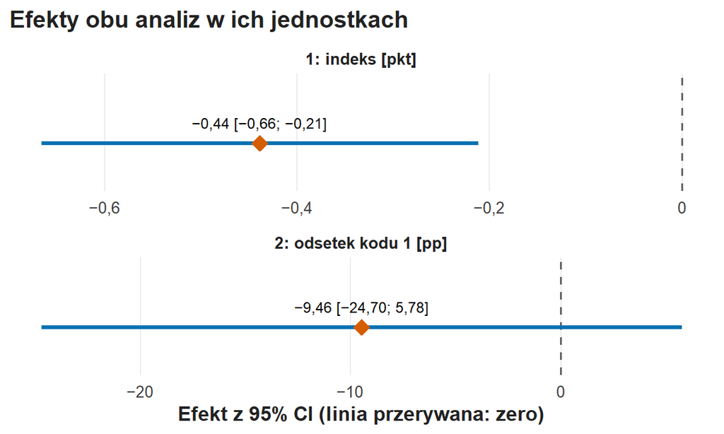

Efekty obu analiz S02 z 95% CI, każdy w swojej jednostce. Górny panel: różnica średnich indeksu, −0,44 punktu, przedział od −0,66 do −0,21. Dolny panel: różnica odsetków kodu 1, −9,46 punktu procentowego, przedział od −24,70 do 5,78. Linia przerywana oznacza zero.

Tabela „Efekty obu analiz z 95% CI” i wykres „Efekty obu analiz w ich jednostkach” zestawiają dwa efekty: różnica indeksu $-0{,}44$ punktu z przedziałem $[-0{,}66; -0{,}21]$ leży w całości poniżej zera, a różnica odsetków $-9{,}46$ pp z przedziałem $[-24{,}70; 5{,}78]$ przecina zero. Panele mają osobne osie, bo punkty indeksu i punkty procentowe to różne jednostki.

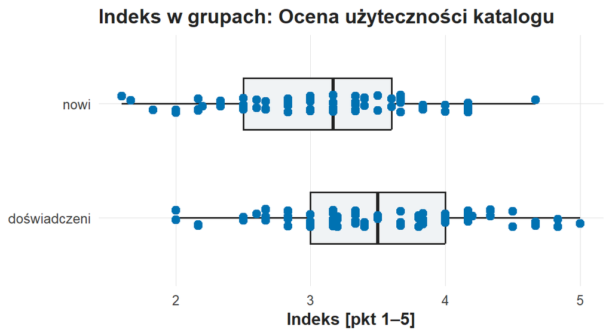

Indeks użyteczności katalogu w grupach S02. Pudełko obejmuje środkowe 50% wyników, kreska oznacza medianę: 3,50 u doświadczonych i 3,17 u nowych; punkty oznaczają osoby.

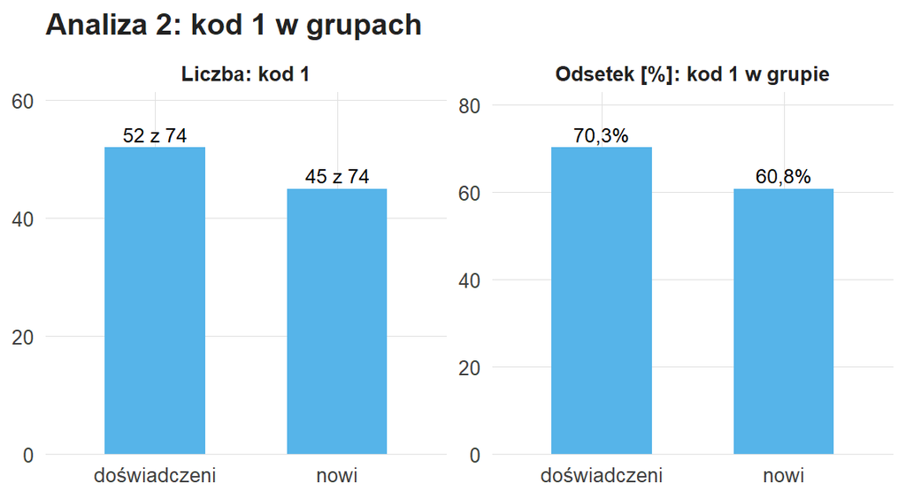

Kod 1 (znaleziony dokument) w grupach S02. Lewy panel: liczba osób z kodem 1; prawy panel: odsetek w grupie, 70,3% (52 z 74) u doświadczonych i 60,8% (45 z 74) u nowych.

```r
obrazy_przykladu <- wykresy_wariantu(analizy_demo)
print(obrazy_przykladu)
```

Wykres indeksu w grupach przedstawia rozkłady z medianą 3,50 u doświadczonych i 3,17 u nowych. Rozkłady w dużej części się nakładają, więc część nowych osób ocenia katalog wyżej niż część doświadczonych. Wykres „Analiza 2: kod 1 w grupach” przedstawia 52 z 74 (70,3%) i 45 z 74 (60,8%) osób z kodem 1. Odczyt zbiorczy opisuje grupy; opis pojedynczej osoby wymagałby jej danych.

Poprawa zmienia przedmiot twierdzenia i nazywa alternatywne wyjaśnienia: doświadczone osoby mogą znać typ dokumentu, częściej korzystać z podobnych baz albo różnić się motywacją. Rozdzielenie alternatywnych wyjaśnień od stażu korzystania wymaga projektu badania, np. pomiaru znajomości typu dokumentu.

**Wzorzec zapisu syntezy (APA).**

> W syntetycznym S02 nowi użytkownicy przeciętnie niżej oceniali użyteczność katalogu (różnica −0,44 punktu, 95% CI [−0,66; −0,21]), a rozkłady ocen obu grup w dużej części się nakładały. Odsetek znalezionych dokumentów był u nowych niższy o 9,5 punktu procentowego, 95% CI [−24,7; 5,8], więc wielkość różnicy skuteczności pozostaje nieustalona. Łącznie wyniki uzasadniają pytanie o bariery pierwszego korzystania z katalogu; znajomość typu dokumentu, korzystanie z podobnych baz i motywacja pozostają alternatywnymi wyjaśnieniami różnicy ocen.

# LEARN 5: Rekomendacja i odtwarzalność

Rekomendacja i odtwarzalność to dwa zobowiązania raportu. Rekomendacja wynika z problemu, pomiaru i siły dowodów; odtwarzalność oznacza ponowne uzyskanie wyników z zapisanych danych i kodu.

$$\text{wynik}=f\big(\text{dane surowe},\ \text{reguły},\ \text{ziarno},\ \text{wersje}\big).$$

Cztery składniki wyznaczają wynik: dane surowe z manifestu, reguły przygotowania, ziarno losowania i wersje oprogramowania. Te same cztery składniki dają ten sam wynik. Hash danych identyfikuje zawartość danych, a suma SHA-256 w potwierdzeniu oddania — wysłaną wersję PDF; trafność pomiaru i poprawność interpretacji ocenia się osobno.

```r
karta_odtworzenia <- slad_analizy(analizy_demo)
print(karta_odtworzenia)
```

**Odtworzenie wyniku**

| Element | Treść |
| --- | --- |
| Wariant danych | demo001 / S02 / 2026-27 |
| Wersja generatora | 1.0.0 |
| Hash danych (pierwsza grupa) | 5f8f14d1 |
| Reguły przygotowania | identyczne duplikaty usunięte; 99 w pozycjach jako brak; czas poza 0–120 min jako brak; pozycja 3 odwrócona; indeks przy co najmniej 5 z 6 pozycji |
| Losowania | B = 1999; ziarno = 202627 |
| Źródła obliczeń | zapisany plik Rmd i towarzyszący mu analiza.R |
| Wersja wysłana | suma SHA-256 z potwierdzenia oddania |

**Wersje środowiska tego wykonania**

| Element | Wersja |
| --- | --- |
| R | 4.6.1 |
| badaniaZI | 2.5.7 |
| knitr | 1.52 |
| rmarkdown | 2.32 |

Karta „Odtworzenie wyniku” podaje wariant demo001 / S02 / 2026-27, wersję generatora 1.0.0, pierwszą grupę hasha 5f8f14d1, reguły przygotowania, $B=1999$ i ziarno 202627. Tabela „Wersje środowiska tego wykonania” podaje wersje R i pakietów użytych do obliczeń.

Dobre zakończenie raportu wskazuje kolejny sprawdzalny krok wynikający z mierzonego konstruktu. Przy danych o zrozumiałości katalogu zalecenie „zwiększyć kompetencje cyfrowe” wykracza poza pomiar, a zalecenie „usunąć filtr” wymaga porównania interfejsów; pilotaż pomocy dla nowych użytkowników jest hipotezą do oceny.

Odtworzenie zaczyna się od zapisanych plików: Rmd z własnymi akapitami i poprawnymi metadanymi oraz `analiza.R` z procedurami tabel. Suma SHA-256 wysłanego PDF powstaje przy oddaniu i pozostaje w potwierdzeniu oraz w pliku `oddania.csv`; wpisanie sumy do pliku, który ona identyfikuje, utworzyłoby nową wersję pliku.

**Wzorzec zapisu rekomendacji (APA).**

> Gdyby podobny wzorzec wystąpił w zaplanowanym badaniu użytkowników, bibliotece warto byłoby najpierw sprawdzić zrozumiałość pomocy i filtrów dla nowych użytkowników, a następnie porównać wersję katalogu z pomocą i bez niej w porównywalnych warunkach. Syntetyczne dane S02 ilustrują analizę, więc rekomendacja dotyczy planu realnego badania. Wyniki odtwarzają zapisane dane (hash zaczynający się od 5f8f14d1), reguły przygotowania, ziarno 202627 i skrypt analizy.

# CHALLENGE — wyniki własnego projektu (Z10)

Pięć zadań stosuje tok LEARN do wariantu zapisanego na C09. Blok CHALLENGE 1 odczytuje zapis Z09: ten sam scenariusz, ID i wariant danych. Akapity S01–S05 przechodzą później do raportu jako pola P05 i P07–P10, więc wszystkie dotyczą liczb własnego wariantu.

Każde z pięciu zadań ma ten sam układ:

1. **Zadanie** — jedno zdanie z przedmiotem opisu.
2. **Blok R** — uruchom go; wynik zawiera wszystkie liczby potrzebne do odpowiedzi.
3. **Wskazówki** — gdzie w wyniku szukać informacji, jak ją nazwać i wzór zdania do uzupełnienia.
4. **W akapicie wymagane** — elementy, które sprawdza prowadzący.
5. **Twój akapit** — pole odpowiedzi w ramce: znacznik w nawiasie kwadratowym zastępujesz własnym tekstem, a linie komentarza nad nim i pod nim pozostawiasz bez zmian.

Akapit liczy 3–6 zdań zwykłego tekstu, bez kodu R. Liczby przepisujesz z wyniku bloku, z jednostką, symbolem i mianownikiem.

## CHALLENGE 1: Wariant i N każdej analizy

**Zadanie:** potwierdź zgodność wariantu z Z09 i opisz dane, na których działają obie analizy.

```r
projekt <- przygotuj_wariant_projektu()
moje_analizy <- analizy_wariantu(projekt)
print(projekt)
```

**Karta wybranego wariantu**

| Element | Treść |
| --- | --- |
| Scenariusz | S02 — Katalog biblioteczny: użyteczność wyszukiwania |
| Problem usługi | Biblioteka chce ustalić, czy katalog wymaga dodatkowego wsparcia przy pierwszych kontaktach. Porównuje ocenę katalogu i wykonanie jednego zadania, ponieważ pozytywna opinia o interfejsie nie musi ozna… |
| Projekt badania | Obserwacyjne badanie przekrojowe; grupy nie są randomizowane. |
| Konstrukt indeksu | Ocena użyteczności katalogu |
| Pierwsze porównanie | nowi minus doświadczeni |
| Druga relacja | grupa × powodzenie znalezienia dokumentu |
| Klucz wariantu (grupy po 8 znaków) | 999176fc 931c08a7 2d4c8ca6 3841b145 8ce3d9c2 ad700c7a aa0fa883 5676db7e |
| Hash SHA-256 danych (grupy po 8 znaków) | 34a356aa 295b519c dc7ed550 aca663be 4a20b960 8da81cc8 6a0b2019 4542358d |

**Manifest wariantu: pochodzenie danych**

| Pole | Wartość |
| --- | --- |
| ID | DEMO_C09 |
| Scenariusz | S02 |
| Rocznik | 2026-27 |
| Wersja generatora | 1.0.0 |
| Rekordy surowe | 150 |
| Wersja R | 4.6.1 |
| Dane syntetyczne | tak |

```r
moje_przygotowanie <- przygotowanie_wariantu(projekt)
print(moje_przygotowanie)
```

**Reguły gotowego skryptu**

| Element | Treść |
| --- | --- |
| Identyczne duplikaty | z kilku identycznych rekordów zostaje jeden; liczba osób maleje |
| Kod 99 | w pozycjach ankiety oznacza brak odpowiedzi i zmienia komórkę na NA; osoba zostaje w danych |
| Czas poza 0–120 min | zmienia komórkę czasu na NA; osoba zostaje w analizach bez czasu |
| Długi czas w zakresie 0–120 min | zostaje jako ważna obserwacja |
| Pozycja 3 | sformułowana odwrotnie; odwrócenie 6 − x nadaje jej kierunek pozostałych pozycji |
| Indeks | średnia sześciu pozycji przy co najmniej 5 ważnych odpowiedziach; przy 4 lub mniej indeks jest brakiem |

**Dziennik przygotowania: wykonane zmiany**

| Reguła | Liczba |
| --- | --- |
| N przed czyszczeniem | 150 |
| Usunięte identyczne duplikaty | 2 |
| Kod 99 zamieniony na NA | 4 |
| Czas poza 0–120 minut zamieniony na NA | 2 |
| N po czyszczeniu | 148 |

```r
moj_bilans <- bilans_wariantu(projekt)
print(moj_bilans)
```

**Bilans liczebności**

| Zakres | N |
| --- | --- |
| Rekordy surowe | 150 |
| Osoby po usunięciu duplikatów | 148 |
| Analiza 1: osoby z ważnym indeksem | 147 |
| Osoby z ważnym czasem | 142 |
| Analiza 2: osoby z wartością 0/1 | 148 |

**Dostępne pomiary w grupach**

| Grupa | Osoby | Ważny indeks | Ważny czas | Najdłuższy ważny czas [min] | Wartość 0/1 |
| --- | --- | --- | --- | --- | --- |
| doświadczeni | 74 | 74 | 69 | 43,9 | 74 |
| nowi | 74 | 73 | 73 | 23,6 | 74 |

Blok wyświetla kartę „Karta wybranego wariantu”, tabelę „Manifest wariantu: pochodzenie danych”, kartę „Reguły gotowego skryptu” oraz tabele „Dziennik przygotowania: wykonane zmiany”, „Bilans liczebności” i „Dostępne pomiary w grupach”.

*Wskazówki:*

- Porównaj ID, scenariusz, rocznik, wersję generatora i pierwszą grupę hasha z akapitem S01 zadania Z09; zgodność pięciu elementów potwierdza ten sam wariant.
- Konstrukt indeksu podaje wiersz „Konstrukt indeksu”, a pomiar drugiego pytania — wiersz „Druga relacja”.
- N analizy 1 i N analizy 2 podaje tabela „Bilans liczebności”; różnica N wynika z różnych zmiennych obu analiz.
- Jedną zmianę z dziennika opisz z liczbą i skutkiem: usunięty rekord zmniejsza liczbę osób, zmieniona komórka zostawia osobę w danych.
- Wzór zdania: „Analizy dotyczą wariantu [ID] / [scenariusz] / [rocznik] (generator [..], hash zaczynający się od [8 znaków]), zgodnego z kartą Z09; dane są syntetyczne. Indeks mierzy [konstrukt], a drugie pytanie — [pomiar]. Analiza 1 objęła [N] osób z ważnym indeksem, a analiza 2 — [N] [osób albo par], ponieważ [..]. Reguła [..] zmieniła [liczba] [rekordów albo komórek], co [skutek]”.

*W akapicie wymagane:* (i) wariant z ID, scenariuszem, rocznikiem, wersją generatora i pierwszą grupą hasha; (ii) konstrukt indeksu i pomiar drugiego pytania; (iii) N obu analiz z wyjaśnieniem różnicy; (iv) jedna zmiana z dziennika z liczbą i skutkiem; (v) informacja o danych syntetycznych.

**Twój akapit S01.** Znacznik w nawiasie kwadratowym zastąp własnym tekstem.

[UZUPELNIJ_S01]

## CHALLENGE 2: Pierwsze porównanie

**Zadanie:** opisz różnicę indeksu między grupami z jej niepewnością i odpowiedz na pierwsze pytanie.

```r
moj_pierwszy_wynik <- wynik_pierwszej_analizy(moje_analizy)
print(moj_pierwszy_wynik)
```

**Analiza 1: kontrast i jednostka**

| Element | Treść |
| --- | --- |
| Pomiar | Ocena użyteczności katalogu |
| Kontrast | nowi minus doświadczeni |
| Jednostka różnicy | punkty indeksu 1–5 |

**Opis grup [pkt 1–5]**

| Grupa | n | Średnia | SD | Mediana |
| --- | --- | --- | --- | --- |
| doświadczeni | 74 | 3,403 | 0,664 | 3,333 |
| nowi | 73 | 3,123 | 0,753 | 3,167 |

**Test Welcha**

| Różnica [pkt] | SE | t | df | p |
| --- | --- | --- | --- | --- |
| −0,280 | 0,117 | −2,392 | 142,29 | 0,0180 |

**95% CI różnicy średnich [pkt]**

| Metoda | Różnica [pkt] | Dolna granica | Górna granica |
| --- | --- | --- | --- |
| Welch | −0,280 | −0,512 | −0,049 |
| Bootstrap w grupach | −0,280 | −0,499 | −0,058 |

**Tasowanie etykiet grup**

| Różnica obserwowana [pkt] | k | B | p_perm |
| --- | --- | --- | --- |
| −0,280 | 31 | 1999 | 0,0160 |

**Efekt standaryzowany**

| Różnica [pkt] | SD łączone | Hedges g |
| --- | --- | --- |
| −0,280 | 0,710 | −0,393 |

Blok wyświetla kartę „Analiza 1: kontrast i jednostka” oraz tabele „Opis grup [pkt 1–5]”, „Test Welcha”, „95% CI różnicy średnich [pkt]”, „Tasowanie etykiet grup” i „Efekt standaryzowany”.

*Wskazówki:*

- Kontrast z karty ustala znak: różnica ujemna oznacza niższą średnią pierwszej grupy z wiersza „Kontrast”.
- Oba przedziały dotyczą różnicy średnich w punktach indeksu; porównaj ich granice.
- $p_{\mathrm{perm}}=(k+1)/(B+1)$: podstaw $k$ i $B$ z tabeli „Tasowanie etykiet grup”.
- Grupy są obserwacyjne, więc odpowiedź na pytanie opisuje związek przynależności do grupy z oceną.
- Wzorzec APA: „Grupa [A] uzyskała średni indeks *M* = [..] (*SD* = [..]; *n* = [..]), a grupa [B] *M* = [..] (*SD* = [..]; *n* = [..]). Różnica [A] minus [B] wyniosła [..] punktu, 95% CI [[..]; [..]], *t*([df]) = [..], *p* = [..], *g* = [..]; bootstrapowy 95% CI wyniósł [[..]; [..]], a test permutacyjny (*B* = [..]) dał *p*<sub>perm</sub> = [..]”.

*W akapicie wymagane:* (i) grupy, pomiar, n, średnie i SD; (ii) różnica ze znakiem w punktach indeksu i Hedges $g$; (iii) CI Welcha i CI bootstrapu z porównaniem granic; (iv) $t$, df i $p$ oraz $k$, $B$ i $p_{\mathrm{perm}}$; (v) odpowiedź na pierwsze pytanie jako opis związku.

**Twój akapit S02.** Znacznik w nawiasie kwadratowym zastąp własnym tekstem.

[UZUPELNIJ_S02]

## CHALLENGE 3: Druga relacja

**Zadanie:** opisz drugą relację scenariusza z efektem, przedziałem i dwoma torami oraz odpowiedz na drugie pytanie.

```r
moj_drugi_wynik <- wynik_drugiej_analizy(moje_analizy)
print(moj_drugi_wynik)
```

**Analiza 2: pole 0/1**

| Element | Treść |
| --- | --- |
| Pytanie | Czy udało się znaleźć wskazany dokument? |
| Kod 1 | wskazano właściwą publikację i jej lokalizację lub dostęp |
| Źródło pola | obserwacja |
| Kontrast | nowi minus doświadczeni |
| Metoda główna | test chi-kwadrat bez korekty ciągłości (wszystkie liczebności oczekiwane co najmniej 5) |

**Liczby i odsetki kodu 1 w grupach**

| Grupa | Kod 0 | Kod 1 | n | Kod 1 [% grupy] |
| --- | --- | --- | --- | --- |
| doświadczeni | 28 | 46 | 74 | 62,2 |
| nowi | 27 | 47 | 74 | 63,5 |

**Test chi-kwadrat bez korekty ciągłości**

| N | Chi-kwadrat | df | p | Najmniejsza oczekiwana | Komórki z oczekiwaną < 5 |
| --- | --- | --- | --- | --- | --- |
| 148 | 0,029 | 1 | 0,8649 | 27,5 | 0 |

**Tabele Monte Carlo przy stałych marginesach**

| Chi-kwadrat obserwowane | k | B | p_MC |
| --- | --- | --- | --- |
| 0,029 | 1999 | 1999 | 1,0000 |

**95% CI różnicy odsetków kodu 1 [pp]**

| Metoda | Różnica [pp] | Dolna granica | Górna granica |
| --- | --- | --- | --- |
| Przybliżenie dużopróbkowe | 1,35 | −14,22 | 16,92 |
| Bootstrap w grupach | 1,35 | −14,86 | 16,22 |

**V Craméra: natężenie bez kierunku**

| V |
| --- |
| 0,014 |

Blok wyświetla wynik jednej z dwóch ścieżek, zgodnie z planem scenariusza: kartę „Analiza 2: pole 0/1” z tabelami liczb i odsetków, testu chi-kwadrat, tabel Monte Carlo, przedziału różnicy odsetków i V Craméra albo kartę „Analiza 2: korelacja rang” z tabelami kompletności par, testu Spearmana, przedziału $r_S$ i tasowania.

*Wskazówki — tabela 2 × 2:*

- Znaczenie kodu 1 podaje wiersz „Kod 1” karty; kierunek „korzystny” wynika z treści pytania.
- Odsetek kodu 1 liczy się w każdej grupie osobno: liczba osób z kodem 1 podzielona przez n grupy.
- Różnica w punktach procentowych ma znak zgodny z kontrastem; V opisuje natężenie związku bez kierunku.
- Wzorzec APA: „[Zdarzenie] dotyczyło [x] z [n] osób w grupie [A] ([..]%) i [x] z [n] w grupie [B] ([..]%); różnica [A] minus [B] wyniosła [..] pp, 95% CI [[..]; [..]]. Test niezależności dał $\chi^2$(1) = [..], *p* = [..], a test Monte Carlo (*B* = [..]) *p*<sub>MC</sub> = [..]; *V* = [..]”.

*Wskazówki — korelacja rang:*

- Znak dodatni $r_S$ oznacza, że wyższy indeks współwystępuje z wyższą wartością drugiej zmiennej, a znak ujemny — z niższą.
- N par podaje tabela „Kompletność par”; statystyka $S$ ma wartość $p$ bez stopni swobody.
- Wzorzec APA: „W [N] kompletnych parach indeks i [zmienna] [kierunek] współwystępowały, *r*<sub>S</sub> = [..], *S* = [..], *p* = [..], bootstrapowy 95% CI [[..]; [..]]; test permutacyjny (*B* = [..]) dał *p*<sub>perm</sub> = [..]”.

*W akapicie wymagane — tabela 2 × 2:* (i) treść kodu 1 oraz odsetki z mianownikami; (ii) różnica w punktach procentowych z CI; (iii) test chi-kwadrat albo Fishera z $p$ i test Monte Carlo z $B$; (iv) V jako natężenie bez kierunku; (v) odpowiedź na drugie pytanie z jednym ograniczeniem pomiaru.

*W akapicie wymagane — korelacja rang:* (i) N par i znaczenie znaku; (ii) $r_S$ z CI bootstrapu par; (iii) $S$, $p$ oraz $p_{\mathrm{perm}}$ z $B$; (iv) skala współczynnika: liczba bez jednostki od $-1$ do $1$; (v) odpowiedź na drugie pytanie z jednym ograniczeniem pomiaru.

**Twój akapit S03.** Znacznik w nawiasie kwadratowym zastąp własnym tekstem.

[UZUPELNIJ_S03]

## CHALLENGE 4: Wspólna interpretacja

**Zadanie:** połącz obie odpowiedzi z problemem usługi i określ granicę wniosku przyczynowego.

```r
moje_efekty <- efekty_projektu(moje_analizy)
print(moje_efekty)
```

**Efekty obu analiz z 95% CI**

| Analiza | Efekt | Jednostka | Estymata | Dolna granica | Górna granica |
| --- | --- | --- | --- | --- | --- |
| 1: indeks | różnica średnich | pkt | −0,28 | −0,51 | −0,05 |
| 2: odsetek kodu 1 | różnica odsetków | pp | 1,35 | −14,22 | 16,92 |

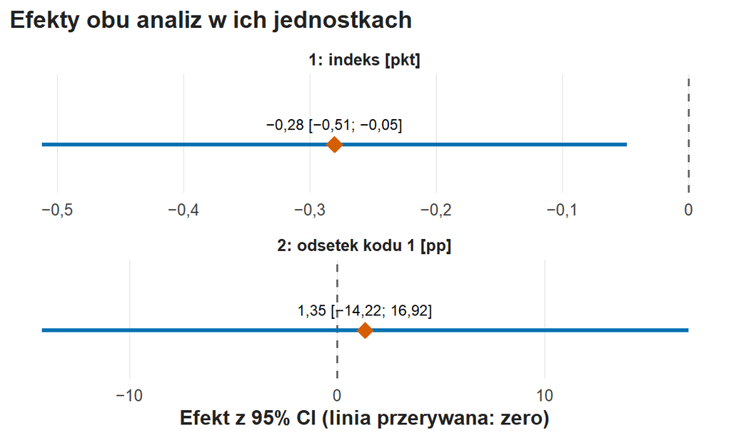

Efekty obu analiz własnego wariantu z 95% CI, każdy w swojej jednostce; linia przerywana oznacza zero.

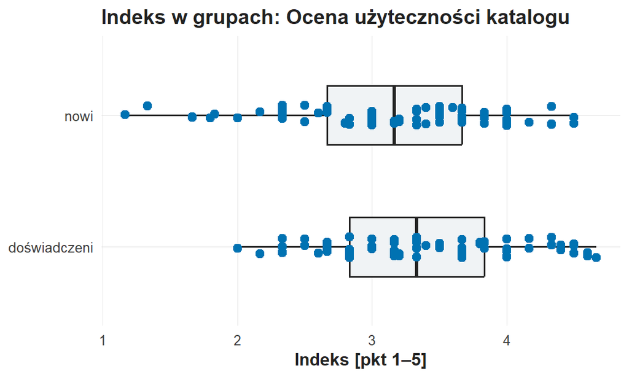

Indeks w grupach własnego wariantu: pudełko obejmuje środkowe 50% wyników, kreska oznacza medianę, punkty oznaczają osoby.

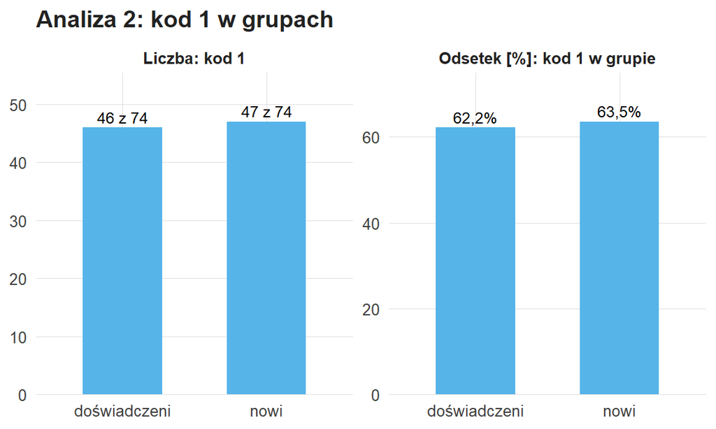

Druga analiza własnego wariantu: kod 1 w grupach (liczba i odsetek) albo kompletne pary indeksu i drugiej zmiennej.

```r
moje_wykresy <- wykresy_wariantu(moje_analizy)
print(moje_wykresy)
```

Blok wyświetla tabelę „Efekty obu analiz z 95% CI”, wykres „Efekty obu analiz w ich jednostkach”, wykres indeksu w grupach i wykres drugiej analizy.

*Wskazówki:*

- Problem usługi podaje karta wariantu z CHALLENGE 1; obie odpowiedzi odnoszą się do problemu usługi.
- Z każdego wykresu weź jedną cechę: nakładanie się rozkładów indeksu, różnicę wysokości słupków albo kształt chmury punktów.
- Przedział po jednej stronie zera opisuje kierunek efektu; przedział przecinający zero pozostawia otwarte kierunek i wielkość efektu.
- Wniosek przyczynowy wymagałby losowego przydziału do grup albo pomiaru przed zmianą i po niej. Alternatywne wyjaśnienie z własnego scenariusza to np. inne zadania, inna motywacja albo wcześniejsza znajomość zasobu.
- Wzór zdania: „W syntetycznym [scenariusz] grupa [A] [wynik 1: efekt z CI], a [wynik 2: efekt z CI]. Wykres [..] pokazuje [..]. Łącznie wyniki uzasadniają [ograniczony wniosek o problemie usługi]; [alternatywne wyjaśnienie] pozostaje możliwe, a wniosek przyczynowy wymagałby [projektu]”.

*W akapicie wymagane:* (i) oba efekty z CI i jednostkami; (ii) jedna cecha każdego z dwóch wykresów wyników; (iii) powiązanie wyników z problemem usługi; (iv) projekt potrzebny do wniosku przyczynowego; (v) jedno alternatywne wyjaśnienie adekwatne do scenariusza.

**Twój akapit S04.** Znacznik w nawiasie kwadratowym zastąp własnym tekstem.

[UZUPELNIJ_S04]

## CHALLENGE 5: Rekomendacja i podstawa odtworzenia

**Zadanie:** zaproponuj proporcjonalny kolejny krok dla instytucji i wskaż, co pozwala sprawdzić podstawę rekomendacji.

```r
moj_slad <- slad_analizy(moje_analizy)
print(moj_slad)
```

**Odtworzenie wyniku**

| Element | Treść |
| --- | --- |
| Wariant danych | DEMO_C09 / S02 / 2026-27 |
| Wersja generatora | 1.0.0 |
| Hash danych (pierwsza grupa) | 34a356aa |
| Reguły przygotowania | identyczne duplikaty usunięte; 99 w pozycjach jako brak; czas poza 0–120 min jako brak; pozycja 3 odwrócona; indeks przy co najmniej 5 z 6 pozycji |
| Losowania | B = 1999; ziarno = 202627 |
| Źródła obliczeń | zapisany plik Rmd i towarzyszący mu analiza.R |
| Wersja wysłana | suma SHA-256 z potwierdzenia oddania |

**Wersje środowiska tego wykonania**

| Element | Wersja |
| --- | --- |
| R | 4.6.1 |
| badaniaZI | 2.5.7 |
| knitr | 1.52 |
| rmarkdown | 2.32 |

Blok wyświetla kartę „Odtworzenie wyniku” i tabelę „Wersje środowiska tego wykonania”.

*Wskazówki:*

- Rekomendacja dotyczy planu realnego badania w instytucji: kolejny sprawdzalny krok to np. pilotaż, porównanie dwóch wersji usługi albo dodatkowy pomiar.
- Powiąż rekomendację z jednym konkretnym wynikiem (efekt z CI) i z najważniejszą niepewnością.
- Zmiana planu realnego badania ogranicza konkretną niepewność: większa próba — precyzję, inny kanał rekrutacji — selekcję, dodatkowy pomiar — zakres konstruktu, losowy przydział — pytanie przyczynowe.
- Podstawę sprawdzenia tworzą zapisane elementy z karty „Odtworzenie wyniku”: dane z hashem, reguły, ziarno, wersje oraz Rmd z `analiza.R`.
- Wzór zdania: „Gdyby podobny wzorzec wystąpił w zaplanowanym badaniu, [instytucja] mogłaby [krok], ponieważ [wynik z CI]. Największą niepewność stanowi [..]; ograniczyłaby ją [zmiana planu]. Dane są syntetyczne, więc rekomendacja dotyczy planu badania. Wyniki odtwarzają zapisane dane (hash zaczynający się od [8 znaków]), reguły przygotowania, ziarno [..] i skrypt analizy”.

*W akapicie wymagane:* (i) proporcjonalny kolejny krok dla instytucji; (ii) powiązanie z konkretnym wynikiem; (iii) najważniejsza niepewność i zmiana planu, która ją ogranicza; (iv) informacja o danych syntetycznych; (v) elementy zapisanej pracy, które pozwalają sprawdzić wynik.

**Twój akapit S05.** Znacznik w nawiasie kwadratowym zastąp własnym tekstem.

[UZUPELNIJ_S05]

# Zapis i oddanie

Sprawdź pięć własnych akapitów: wariant zgadza się z Z09, liczby pochodzą z wydruków własnego wariantu, a znak, jednostka i mianownik każdego efektu są zgodne z tabelą. Zapisz plik `zadanie.Rmd` w edytorze (Ctrl+S); funkcja oddania tworzy PDF z zapisanego pliku.

W konsoli wykonaj jedno polecenie. Funkcja oddania tworzy aktualny PDF, sprawdza kompletność, otwiera PDF do obejrzenia i po potwierdzeniu literą `t` wysyła go do folderu zadania prowadzącego na serwerze UJ (nc.uj.edu.pl). Rmd, `analiza.R` i dane wariantu zostają w folderze `moje-badania` do raportu projektu.

```r
oddaj_zadanie("Z10")
```

Oddanie potwierdza komunikat z nazwą wysłanego pliku, folderem i czasem; plik `oddania.csv` w folderze `moje-badania` zapisuje także sumę SHA-256 wysłanego PDF. Po komunikacie błędu popraw wskazany problem, zapisz plik i ponownie wywołaj `oddaj_zadanie("Z10")`; nowa wersja trafia do folderu obok poprzedniej. Ocenę prowadzący przekazuje osobno.

Po potwierdzonym oddaniu możesz zamknąć projekt: Posit Cloud zachowuje folder `moje-badania` do kolejnych zajęć. Na komputerze współdzielonym wyloguj się z Posit Cloud w przeglądarce. Ćwiczenie C10 zamyka cykl ćwiczeń; dalsza praca to redakcja raportu projektu.

## Co jest oceniane

| Kryterium | Dowód w Twojej pracy | Odpowiedzi | Punkty |
| --- | --- | --- | --- |
| Z10.1 Ten sam wariant i odtworzenie obu analiz | Wariant zgodny z Z09; pomiar, reguły przygotowania i N obu analiz; analizy odtwarzają się w świeżej sesji | S01 | 3 |
| Z10.2 Pięć własnych odpowiedzi i zgodny PDF | Pięć akapitów poza kodem; PDF z tego samego Rmd zawiera akapity, tabele i wykresy | S01–S05 | 2 |
| Z10.3 Interpretacja dwóch relacji i obu torów | Efekty z jednostkami, CI i oba tory; synteza bez wniosku przyczynowego; proporcjonalna rekomendacja | S02–S05 | 3 |
| Z10.4 Potwierdzenie oddania i opis odtworzenia | Karta odtworzenia w PDF zgodna z zapisanymi źródłami, danymi i manifestem; potwierdzenie oddania z sumą SHA-256 | S01–S05 | 2 |

Ocena dotyczy poprawności odczytu i proporcjonalności wniosku. Poziomy wykonania opisuje rubryka Z10: na stronie kursu w dokumencie `rubryki/Z10.html`, a w konsoli R po poleceniu `rubryka("Z10")`.

# Projekt końcowy: raport z dziesięciu akapitów

Po oddaniu Z09 i Z10 projekt końcowy powstaje z tych samych akapitów. Raport ma dziewięć rozdziałów i jedenaście pól: dziesięć pól przejmuje akapity CHALLENGE, a pole P11 (bibliografia i zakres wsparcia narzędzi SI) wypełnia się w raporcie.

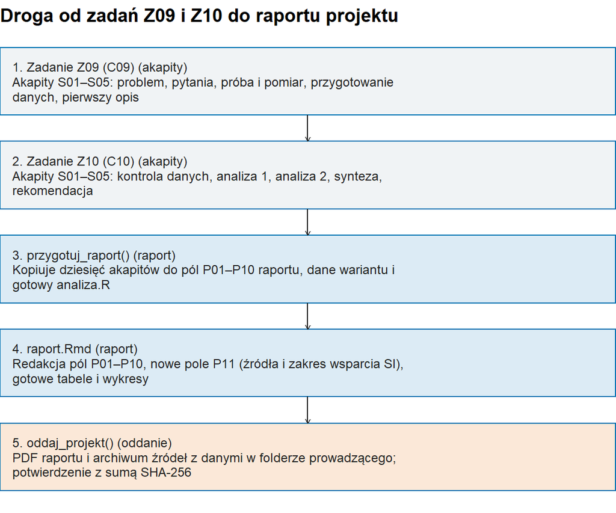

Droga od zadań do raportu w pięciu krokach, od góry do dołu: akapity Z09 i Z10, funkcja przygotowania raportu kopiująca je do pól P01–P10, redakcja pliku raportu z nowym polem P11 i oddanie projektu do folderu prowadzącego z potwierdzeniem i sumą SHA-256.

```r
droga <- pokaz_wykres(droga_raportu())
print(droga)
```

```r
mapa <- mapa_projektu()
print(mapa)
```

**Raport projektu: jedenaście pól i ich źródła**

Pole

Rozdział raportu

Akapit źródłowy

P01

1. Problem informacyjny i cel

Z09 S01

P02

2. Pytania, estymandy i plan analiz

Z09 S02

P03

3. Populacja, rekrutacja i operacjonalizacja

Z09 S03

P04

4. Dane i reguły przygotowania

Z09 S04

P05

4. Dane i reguły przygotowania

Z10 S01

P06

5. Opis próby i pomiarów

Z09 S05

P07

6. Pierwsza analiza

Z10 S02

P08

7. Druga analiza

Z10 S03

P09

8. Wnioski i ograniczenia

Z10 S04

P10

8. Rekomendacja

Z10 S05

P11

9. Źródła i odtworzenie

nowe pole raportu

Wykres „Droga od zadań Z09 i Z10 do raportu projektu” przedstawia pięć kroków: akapity Z09, akapity Z10, funkcję `przygotuj_raport()`, redakcję pliku `raport.Rmd` i oddanie funkcją `oddaj_projekt()`. Tabela „Raport projektu: jedenaście pól i ich źródła” przypisuje akapity polom raportu: akapit Z10 S01 staje się polem P05, a akapity Z10 S02–S05 — polami P07–P10.

## Sześć kroków pracy nad raportem

1. Zapisz i oddaj zadania Z09 i Z10.
2. W konsoli wykonaj `przygotuj_raport()`. Funkcja tworzy katalog `projekty/ilosciowy` z plikiem `raport.Rmd`, kopią danych wariantu i gotowym `analiza.R`; dziesięć akapitów trafia do pól P01–P10, a pola bez akapitu czekają na uzupełnienie.
3. Otwórz plik `projekty/ilosciowy/raport.Rmd` i uruchom bloki od pierwszego. Każdy rozdział raportu ma układ zadania CHALLENGE: komentarz z zadaniem, wskazówkami i wymaganymi elementami (widoczny w edytorze RStudio, pominięty w PDF), gotowy blok R i pole odpowiedzi.
4. Zredaguj pola P01–P10 w jeden tekst: usuń powtórzenia, uzgodnij liczby z tabelami raportu i dopisz przejścia między rozdziałami.
5. Wypełnij pole P11: źródła w formacie APA z informacją, do czego służą w raporcie, oraz opis faktycznego wsparcia narzędzi SI.
6. Zapisz plik i w konsoli wykonaj `oddaj_projekt()`.

```r
przygotuj_raport()
oddaj_projekt()
```

Ponowne wywołanie `przygotuj_raport()` otwiera istniejący raport z poprawkami; akapity z Z09 i Z10 kopiuje się raz. Raport korzysta z tych samych pytań i danych co Z09 i Z10, a gotowe bloki R raportu tworzą tabele i wykresy z zapisanego wariantu.

| Element przygotowany w Z09 | Uzupełnienie z Z10 | Miejsce w raporcie |
| --- | --- | --- |
| problem, dwa pytania i estymandy | odpowiedzi na te pytania | cel i wnioski |
| populacja, rekrutacja, pomiar | ograniczenia uogólnienia i konstruktu | metoda i ograniczenia |
| reguły, dane i manifest | faktyczne N obu analiz | przygotowanie danych |
| pierwszy opis grup | efekty, CI, testy i wykres drugiej relacji | wyniki |
| uzasadnienie planu | proporcjonalny następny krok | dyskusja i rekomendacja |

# Rozwinięcia do powtórki i redakcji raportu

Siedem rozwinięć omawia typowe trudności przy redakcji raportu: efekt i precyzję, odczyt Monte Carlo, połączenie planu z wynikiem, poziomy pomiaru, ograniczenia, korektę liczb i zakres odtwarzalności. Rozwinięcia pozostają poza oceną Z10.

## 1. Efekt, precyzja i decyzja: trzy informacje

Trzy oszacowania różnicy ocen usługi są hipotetyczne: dwa mają wartość punktową 0,2 i różne przedziały, trzecie wskazuje większą różnicę.

```r
porownanie_precyzji <- precyzja_do_raportu()
print(porownanie_precyzji)
```

**Trzy hipotetyczne oszacowania różnicy**

| Wariant | Estymata [pkt] | Dolna granica | Górna granica |
| --- | --- | --- | --- |
| Szeroki | 0,2 | −0,5 | 0,9 |
| Precyzyjnie mały | 0,2 | 0,1 | 0,3 |
| Wyraźna różnica | 0,8 | 0,5 | 1,1 |

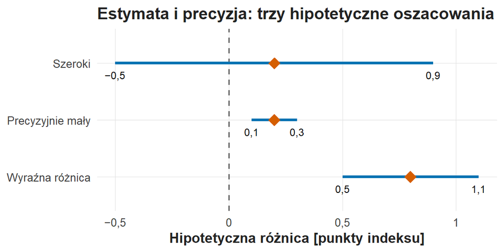

Trzy hipotetyczne oszacowania różnicy w punktach indeksu z 95% CI. Szeroki: 0,2 [−0,5; 0,9]; precyzyjnie mały: 0,2 [0,1; 0,3]; wyraźna różnica: 0,8 [0,5; 1,1]. Linia przerywana oznacza zero.

Tabela „Trzy hipotetyczne oszacowania różnicy” i wykres „Estymata i precyzja: trzy hipotetyczne oszacowania” oddzielają położenie punktu od długości przedziału. Wariant szeroki, 0,2 z przedziałem $[-0{,}5; 0{,}9]$, obejmuje różnice ujemne i dodatnie o wyraźnej wielkości. Wariant precyzyjnie mały, 0,2 z przedziałem $[0{,}1; 0{,}3]$, ogranicza niepewność, a decyzja o koszcie zmiany usługi wymaga kryterium praktycznej ważności. Wariant 0,8 z przedziałem $[0{,}5; 1{,}1]$ opisuje większą różnicę; jej przyczyna wymaga projektu badania.

Próg praktycznej ważności uzasadnia się pomiarem i decyzją. Dwie minuty oszczędzone przy częstym, prostym zadaniu ważą inaczej niż przy rzadkim przeglądzie literatury, a 0,2 punktu indeksu deklaracji wymaga odniesienia do treści pozycji. Koszt zmiany, dostępność i ryzyko wykluczenia użytkowników również należą do decyzji. Równoważność wykazuje test z granicą praktycznie zaniedbywalnej różnicy ustaloną przed analizą; raport projektu nazywa pytania, które pozostają otwarte.

## 2. Odczyt Monte Carlo

$$p_{\mathrm{MC}}=\frac{k+1}{B+1}.$$

Symbol $B$ oznacza liczbę losowań przy modelu zerowym, a $k$ — liczbę statystyk co najmniej tak skrajnych jak obserwowana. Dla testu dwustronnego różnicy porównuje się wartości bezwzględne, a dla $\chi^2$ skrajność obejmuje duże wartości dodatnie.

W S02 pierwsze porównanie ma $k=1$ przy $B=1999$, więc $p_{\mathrm{perm}}=2/2000=0{,}001$. Tabela krzyżowa ma $k=593$, stąd $p_{\mathrm{MC}}=594/2000=0{,}297$. W przykładzie korelacyjnym S05 $k=462$ daje $463/2000=0{,}2315$. Trzy wartości $p$ dotyczą trzech modeli zerowych i trzech pytań.

Dodanie jedynki w liczniku i mianowniku sprawia, że najmniejsza możliwa wartość przy $B=1999$ wynosi $1/2000=0{,}0005$ (Phipson i Smyth, 2010). Większe $B$ poprawia rozdzielczość i zmniejsza błąd Monte Carlo; pomiar, zależność obserwacji i schemat tasowania ocenia projekt. Ziarno losowania ustala się przed analizą, a ponowne uruchomienie zapisanego kodu sprawdza odtwarzalność.

Oba tory korzystają z tych samych osób, więc ich zgodność opisuje zgodność metod na jednej próbie. Rozbieżność torów ma kilka możliwych źródeł: przybliżenie rozkładu, dyskretność, warunkowanie na marginesach, remisy rang albo inne założenia hipotezy zerowej. Odczyt rozbieżności zaczyna się od N, statystyki i procedury.

## 3. Plan i wynik w jednym raporcie

Karta Z09 określiła pytania przed odczytem testów. W raporcie końcowym pozostają te same pytania, ta sama definicja indeksu i ten sam wariant danych, a akapity Z10 dostarczają odpowiedzi. Zmianę planu raportuje się jawnie wraz z jej powodem i konsekwencją.

Raport podaje, co porównano, jak powstał pomiar, ile osób weszło do analizy i co oznacza znak efektu. Część metodyczna rozdziela plan realnego badania od wykonanej analizy syntetycznej: „W planowanym badaniu zaproszeni zostaną użytkownicy…; w projekcie dydaktycznym analizowano wygenerowany wariant…”. Rekrutację, obserwację i zgody opisuje się jako plan.

Przygotowanie danych opisuje się przez regułę i jej rezultat: co uznano za duplikat, gdzie kod 99 oznacza brak, ile pomiarów utracono i dlaczego osoba bez czasu zostaje w pozostałych analizach. Surowe dane i manifest służą odtworzeniu, a dziennik i bilans N — wyjaśnieniu.

## 4. Deklaracja, wykonanie i kompetencja

Odpowiedź „łatwo odnajduję potrzebne treści” opisuje doświadczenie lub samoocenę osoby. Poprawne odnalezienie dokumentu opisuje wykonanie konkretnego zadania w określonych warunkach. Twierdzenie o kompetencjach wymaga uzasadnienia, że zestaw zadań i kryteriów obejmuje interesujący zakres umiejętności.

Różnica deklaracji i wykonania ma kilka źródeł: inne zadania odniesienia, inna grupa porównawcza, inne rozumienie słowa „łatwo”. Niski związek samooceny z czasem wskazuje na dwa odrębne konstrukty, a wysoki związek opisuje współzmienność dwóch pomiarów.

Hargittai (2002) uzasadnia pomiar wykonania obok deklaracji, a Internet Skills Scale (van Deursen, Helsper i Eynon, 2016) ilustruje wielowymiarowy pomiar umiejętności. Nazwa konstruktu wynika z treści pozycji. Znaczenie kodu 1 wynika z treści pytania: „ponownie skorzystam z repozytorium” jest deklaracją zamiaru, a „znalazłem sprzeczne informacje” — zdarzeniem niekorzystnym. Projekt rozdziela poziomy deklaracji, wykonania i kompetencji; rekomendacja wykraczająca poza mierzony konstrukt zawęża się albo proponuje dodatkowy pomiar.

## 5. Ograniczenie zmienia interpretację

Dobre ograniczenie wskazuje mechanizm i jego konsekwencję dla wniosku. Rekrutacja wyłącznie wśród aktywnych użytkowników katalogu pomija osoby, które z niego zrezygnowały, więc opis doświadczeń może pomijać największe bariery.

Osoby, które przerwały zadanie, mogą różnić się od osób, które ukończyły zadanie; analiza kompletnych par opisuje osoby z kompletem danych. Raport podaje, jak reguła braków określa osoby objęte wnioskiem.

Staż korzystania współwystępuje ze znajomością dziedziny, częstotliwością korzystania i warunkami dostępu. Różnica średnich pozostaje użytecznym opisem, a przypisanie jej samemu doświadczeniu wymagałoby innego projektu; kontrola zmiennej wymaga planu i analizy.

Krótszy czas ma kilka znaczeń: sprawne wykonanie, szybką rezygnację albo pobieżną ocenę źródła. Czas czyta się razem z kryterium ukończenia i jakością wykonania.

Dane syntetyczne służą ćwiczeniu procedur i języka wnioskowania, więc wniosek praktyczny ma formę warunkowej propozycji przyszłego sprawdzenia.

## 6. Korekta tekstu: liczba i znaczenie

Zdanie „grupa uzyskała wynik 3,5” pozostawia otwarte, czy chodzi o średnią, medianę czy indeks i jaki jest jego zakres. Zdanie „średni indeks deklarowanej użyteczności wyniósł 3,5 punktu na skali 1–5” ustala pomiar i jednostkę; N i SD opisują podstawę i zróżnicowanie, a przedział — precyzję estymaty.

$$60\% - 70\% = -10\ \text{pp},\qquad \frac{60-70}{70}\cdot100\% = -14{,}3\%.$$

Porównanie 60% i 70% daje dwie różne miary: różnicę $-10$ punktów procentowych w kierunku pierwsza minus druga grupa oraz zmianę względną $-14{,}3\%$ wobec 70%. Każda miara ma własny mianownik, a raport podaje miarę zgodną z estymandą z planu.

Przedział dla parametru opisuje niepewność oszacowania różnicy przy założeniach metody; zakres wyników pojedynczych osób opisuje rozkład, np. wykres pudełkowy. Poziom 95% odnosi się do własności procedury w powtarzanych próbach.

Wartość $p$ opisuje skrajność statystyki przy modelu zerowym i procedurze; efekt opisują estymata i przedział. Zdanie „$p = 0{,}03$ oznacza 97% pewności efektu” miesza skrajność statystyki z pewnością efektu.

Korelacja $r_S=-0{,}4$ jest liczbą bez jednostki i opisuje rangowy związek monotoniczny. Nachylenie regresji ma jednostkę, np. minut na punkt indeksu, a efekt interwencji wymaga eksperymentu.

## 7. Zakres kontroli odtwarzalności

Świeże renderowanie potwierdza, że zapisane źródła ponownie wytwarzają tabele i wykresy. Wartość pytania, reprezentatywność próby, trafność pomiaru i adekwatność języka ocenia się osobno: analiza może być w pełni odtwarzalna i odpowiadać na źle postawione pytanie.

Weryfikacja idzie w obie strony: od akapitu do liczby i od liczby do pytania. Przedział innej zmiennej w akapicie albo proporcje w kolumnach przy pytaniu o proporcje w grupach to błędy odczytu, które świeże renderowanie zachowuje.

Tożsamość danych potwierdza manifest: ten sam identyfikator osoby przy innym scenariuszu albo wersji generatora daje inne dane. PDF powstaje z aktualnego Rmd, więc zmiana akapitu zmienia wynikowy PDF. Potwierdzenie zdalne identyfikuje odebraną wersję plików; błąd wysyłki zgłasza się prowadzącemu, a praca pozostaje w katalogu studenta i jego repozytorium.

## Źródła i ich rola w raporcie

[Wilson (1999), modele zachowań informacyjnych](https://informationr.net/tdw/publ/papers/1999JDoc.html), osadza korzystanie z katalogu w szerszym problemie potrzeb, kontekstu i barier; pojedynczy czas zadania jest jednym wskaźnikiem tego zachowania.

[Hargittai (2002), pomiar rzeczywistych umiejętności internetowych](https://webuse.org/p/a09/), oraz [van Deursen, Helsper i Eynon (2016), Internet Skills Scale](https://eprints.lse.ac.uk/64485/), pomagają rozdzielić wykonanie, deklarację i zakres konstruktu.

[Stanowisko ASA o wartościach p (Wasserstein i Lazar, 2016)](https://doi.org/10.1080/00031305.2016.1154108) uzasadnia raportowanie efektu, niepewności i kontekstu obok wartości $p$. [Phipson i Smyth (2010)](https://doi.org/10.2202/1544-6115.1585) wyjaśniają dodanie jedynki we wzorze na $p$ z losowanych permutacji.

Pełne opisy bibliograficzne zawiera bibliografia kursu. Liczby w przykładach C10 pochodzą z danych syntetycznych albo z jawnie hipotetycznych demonstracji, a cytowane badania pomagają formułować pytania i granice interpretacji.